# Modeling Exchange-Rate data using ARIMA

**Rohith Krishna**  
**July 14, 2020**

Back to project page

# Exploratory Data Analysis

```python
import pandas as pd
import numpy as np
import matplotlib.pyplot as plt
from scipy import stats
from scipy.stats import kurtosis
from scipy.stats import skew
import statsmodels.api as sm

from datetime import datetime
from datetime import timedelta
from pandas.plotting import register_matplotlib_converters
from statsmodels.graphics.tsaplots import plot_acf, plot_pacf
from statsmodels.tsa.stattools import adfuller
from statsmodels.tsa.stattools import acf, pacf
from statsmodels.tsa.stattools import kpss
from statsmodels.tsa.arima_model import ARMA
from statsmodels.tsa.arima_model import ARIMA
from time import time
register_matplotlib_converters()
```

```python
# importing the daily data
df_daily = pd.read_excel(r'/Users/rohith/Documents/RBIinternship/final-report/data-jan16-jun20-daily.xlsx')
df_daily.head()
```

|  | time | inrVal | returns | diff |
| --- | --- | --- | --- | --- |
| 0 | 2016-01-01 | 66.1537 | 0.000000 | 0.0000 |
| 1 | 2016-01-02 | 66.1537 | 0.000000 | 0.0000 |
| 2 | 2016-01-03 | 66.1537 | 0.000000 | 0.0000 |
| 3 | 2016-01-04 | 66.6333 | 0.007224 | 0.4796 |
| 4 | 2016-01-05 | 66.5865 | -0.000703 | -0.0468 |

```python
# convert time to datetime type
df_daily['time'] = pd.to_datetime(df_daily.time)

# set date as index
df_daily.set_index('time', inplace=True)
start_date = pd.to_datetime('2016-01-01')
df_daily = df_daily[start_date:]
df_daily.head()

# calculating first differences
df_daily.diff = df_daily.inrVal.diff()[1:]
```

### Summary statistics of the data

```python
print("Exchange Rates \n-------------------- ")
print(df_daily.inrVal.describe())
print('kurtosis ', kurtosis(df_daily.inrVal))
print('skewness ', skew(df_daily.inrVal))
```

```
Exchange Rates
--------------------
count    1643.000000
mean       68.481222
std         3.265543
min        63.369900
25%        66.226000
50%        67.995500
75%        70.969700
max        76.936400
Name: inrVal, dtype: float64
kurtosis  -0.3971000535624869
skewness  0.5334319860507775
```

### Plotting Exchange Rates

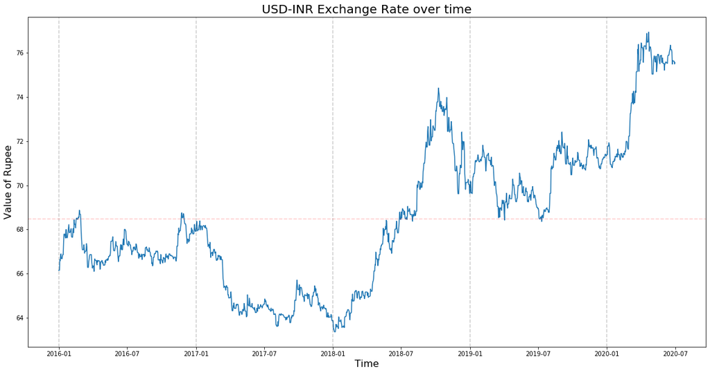

```python
plt.figure(figsize=(20,10))
plt.plot(df_daily.inrVal)
plt.title('USD-INR Exchange Rate over time', fontsize=20)
plt.ylabel('Value of Rupee', fontsize=16)
plt.xlabel('Time', fontsize=16)
for year in range(2016,2021):
    plt.axvline(pd.to_datetime(str(year)+'-01-01'), color='k', linestyle='--', alpha=0.2)
plt.axhline(df_daily.inrVal.mean(), color='r', alpha=0.2, linestyle='--')
plt.savefig('daily-data.png',dpi=300, bbox_inches='tight')
plt.show()
```

There are periods of high volatility. Although the Rupee value seems to have depreciated vis-a-vis the US Dollar, we are unable determine stationarity visually and require a statistical test such as Augmented Dickey Fuller Test.

The vertical dashed gray lines indicate the beginning of each year. The horizontal red line is the mean Rupee value for the entire period. Clearly, the time series data falls below the mean in the period 2016-17 and rises much above the mean in 2019-20. This increasing trend in the mean Rupee value owing to currency depreciation means that the data cannot be stationary.

## Autocorrelation Function

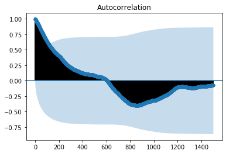

```python
plt.figure(figsize=(20,10))
acf_plot = plot_acf(df_daily.inrVal, lags=1500)
plt.savefig('acf-daily-1500-lags.png',dpi=300, bbox_inches='tight')
```

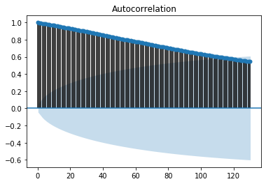

```python
plt.figure(figsize=(20,10))
acf_plot = plot_acf(df_daily.inrVal, lags=130)
plt.savefig('acf-daily-130-lags.png',dpi=300, bbox_inches='tight')
```

## Partial Autocorrelations

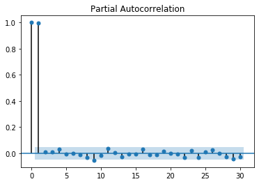

```python
plt.figure(figsize=(20,10))
pacf_plot = plot_pacf(df_daily.inrVal, lags=30)
plt.savefig('pacf-daily-30-lags.png',dpi=300, bbox_inches='tight')
```

> In R, we use the following code to obtain autocorrelations:

> ```
> par(mfrow=c(1,2))
> acf(df_daily$inrVal)
> pacf(df_daily$inrVal)
> ```

[figure not shown]

## Tests for Stationarity

It seems that the series exhibits both AR(p) and MA(q) terms. But to be certain one has to conduct tests for stationarity on the data using statistical tests such as the Augmented Dickey Fuller test.

### Types of stationarity

- Strict Stationary: Satisfies the mathematical conditions for strict stationarity.
- Trend Stationary: Series that has no unit root but exhibits a trend. Once the trend is removed, the resulting series will be strict stationary. The KPSS test classifies a series as stationary on the absence of unit root. This means that the series can be strict stationary or trend stationary.
- Difference Stationary: A time series that can be made strict stationary by differencing falls under difference stationary. ADF test is also known as a difference stationarity test.

Case 1: Both tests conclude that the series is not stationary -> series is not stationary

Case 2: Both tests conclude that the series is stationary -> series is stationary

Case 3: KPSS = stationary and ADF = not stationary -> trend stationary, remove the trend to make series strict stationary

Case 4: KPSS = not stationary and ADF = stationary -> difference stationary, use differencing to make series stationary

### Augmented Dickey Fuller (ADF) Test on original data

The hypotheses at 5 percent significance level are:

$H_0$: The time series is not stationary.  
$H_1$: The time series is stationary.

Our objective is to reject the null hypothesis when the p-value is less that 0.05 and ensure stationarity of the time series data

```python
#define function for ADF test
from statsmodels.tsa.stattools import adfuller
def adf_test(timeseries):
    #Perform Dickey-Fuller test:
    print ('Results of Dickey-Fuller Test: \n')
    dftest = adfuller(timeseries, autolag='AIC')
    dfoutput = pd.Series(dftest[0:4], index=['Test Statistic','p-value','#Lags Used','Number of Observations Used'])
    for key,value in dftest[4].items():
       dfoutput['Critical Value (%s)'%key] = value
    print (dfoutput)

#apply adf test on the series
adf_test(df_daily.inrVal)
```

```
Results of Dickey-Fuller Test:

Test Statistic                   -0.427478
p-value                           0.905409
#Lags Used                        0.000000
Number of Observations Used    1642.000000
Critical Value (1%)              -3.434339
Critical Value (5%)              -2.863302
Critical Value (10%)             -2.567708
dtype: float64
```

Since p-value is greater that 0.05, we cannot reject the null hypothesis. The exchange rate time series is in fact non-stationary.

This calls for a transformation that would make the data stationary. One could calculate the differences or obtain the logarithmic returns of the exchange rate data. The reason one uses returns rather than actual exchange rate values is that returns have more suitable statistical properties than rates (CAMPBELL). Logarithmic returns (continuously compounded returns) are used frequently, which we adopt here.

The log returns are defined as follows.

$$ r_t = \ln\left(\frac{y_t}{y_{t-1}}\right) $$

### Plotting first differences

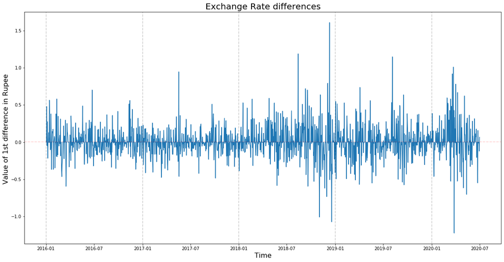

```python
plt.figure(figsize=(20,10))
plt.plot(df_daily.diff)
plt.title('Exchange Rate differences', fontsize=20)
plt.ylabel('Value of 1st difference in Rupee ', fontsize=16)
plt.xlabel('Time', fontsize=16)
for year in range(2016,2021):
    plt.axvline(pd.to_datetime(str(year)+'-01-01'), color='k', linestyle='--', alpha=0.2)
plt.axhline(df_daily.diff.mean(), color='r', alpha=0.2, linestyle='--')
plt.savefig('daily-data-diff.png',dpi=300, bbox_inches='tight')
plt.show()
```

### Plotting exchange rate log returns

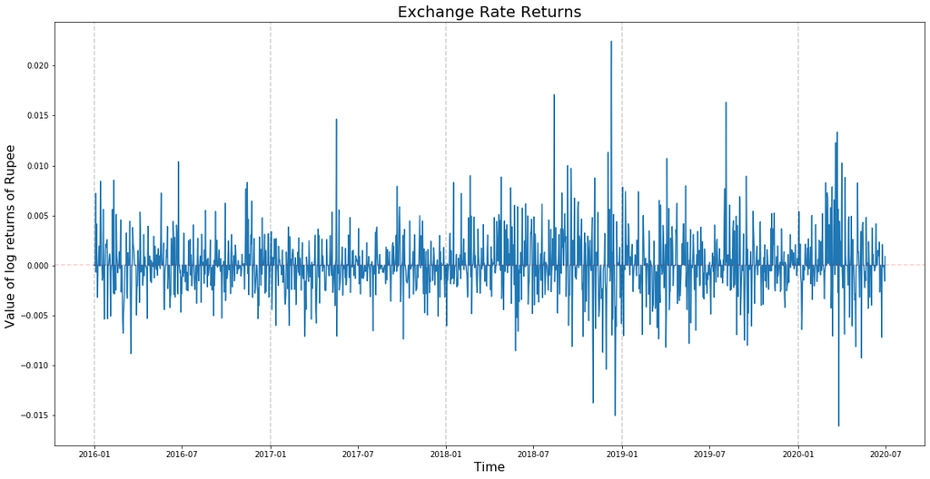

```python
plt.figure(figsize=(20,10))
plt.plot(df_daily.returns)
plt.title('Exchange Rate Returns', fontsize=20)
plt.ylabel('Value of log returns of Rupee ', fontsize=16)
plt.xlabel('Time', fontsize=16)
for year in range(2016,2021):
    plt.axvline(pd.to_datetime(str(year)+'-01-01'), color='k', linestyle='--', alpha=0.2)
plt.axhline(df_daily.returns.mean(), color='r', alpha=0.2, linestyle='--')
plt.savefig('daily-data-returns.png',dpi=300, bbox_inches='tight')
plt.show()
```

### ADF test on log returns

```python
adf_test(df_daily.returns)
```

```
Results of Dickey-Fuller Test:

Test Statistic                  -40.987766
p-value                           0.000000
#Lags Used                        0.000000
Number of Observations Used    1642.000000
Critical Value (1%)              -3.434339
Critical Value (5%)              -2.863302
Critical Value (10%)             -2.567708
dtype: float64
```

An ADF of -40.987766 is obtained with p-value < 0.05. Hence the tranformed data is stationary. This can be confirmed by plotting the ACF and PACF of the log return data.

### ACF and PACF of log returns data

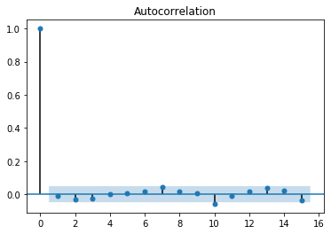

```python
plt.figure(figsize=(20,10))
acf_plot = plot_acf(df_daily.returns, lags=15)
plt.savefig('acf-daily-returns-15lags.png',dpi=300, bbox_inches='tight')
```

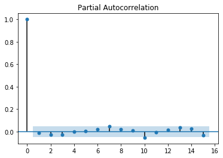

```python
plt.figure(figsize=(20,10))
pacf_plot = plot_pacf(df_daily.returns, lags=15)
plt.savefig('pacf-daily-returns-15lags.png',dpi=300, bbox_inches='tight')
```

From the ACF, we should start with an MA(1) model.  
From the PACF, we should start with an AR(10) model.

```python
print("Exchange Rate Log Returns  \n------------------------- ")
print(df_daily.returns.describe())
print('kurtosis ', kurtosis(df_daily.returns))
print('skewness ', skew(df_daily.returns))
```

```
Exchange Rate Log Returns
-------------------------
count    1643.000000
mean        0.000081
std         0.002906
min        -0.016115
25%        -0.000967
50%         0.000000
75%         0.000923
max         0.022457
Name: returns, dtype: float64
kurtosis  6.282567533175008
skewness  0.6196838790979041
```

The mean of the returns data is 0, indicative of a normal distribution. However, the kurtosis > 3 means that it is leptokurtic in nature. (COPPES)

### Shapiro-Wilk Test of Normality

The Shapiro–Wilk test checks whether the sample came from a normally distributed population. The null hypothesis that is that the data is normally distributed, which is rejected with a p-value less than 0.05.

```python
shapiro_test = stats.shapiro(df_daily.returns)
shapiro_test
```

```
ShapiroResult(statistic=0.8919786214828491, pvalue=1.890033579522588e-32)
```

The results show that $W = 0.892 $ with p <0.05. Hence reject the null hypothesis and conclude that the returns are not normally distributed. (CANAN CORLU 2013)

### Kwiatkowski-Phillips-Schmidt-Shin (KPSS) Test

The KPSS test is also used to test for stationarity of time-series data. The null hypothesis for the KPSS test and the ADF test are opposites.

The hypotheses at 5 percent significance level are:

$H_0$: The time series is trend stationary.  
$H_1$: The time series a unit root (series is not stationary).

```python
# KPSS on exchange rate value
def kpss_test(series, **kw):
    statistic, p_value, n_lags, critical_values = kpss(series, **kw)
    # Format Output
    print(f'KPSS Statistic: {statistic}')
    print(f'p-value: {p_value}')
    print(f'num lags: {n_lags}')
    print('Critial Values:')
    for key, value in critical_values.items():
        print(f'   {key} : {value}')
    print(f'Result: The series is {"not " if p_value < 0.05 else ""}stationary')

kpss_test(df_daily.inrVal)
```

```
KPSS Statistic: 3.8643306549809835
p-value: 0.01
num lags: 25
Critial Values:
   10% : 0.347
   5% : 0.463
   2.5% : 0.574
   1% : 0.739
Result: The series is not stationary
```

```python
# KPSS on log returns
def kpss_test(series, **kw):
    statistic, p_value, n_lags, critical_values = kpss(series, **kw)
    # Format Output
    print(f'KPSS Statistic: {statistic}')
    print(f'p-value: {p_value}')
    print(f'num lags: {n_lags}')
    print('Critial Values:')
    for key, value in critical_values.items():
        print(f'   {key} : {value}')
    print(f'Result: The series is {"not " if p_value < 0.05 else ""}stationary')


kpss_test(df_daily.returns)
```

```
KPSS Statistic: 0.15777622307989894
p-value: 0.1
num lags: 25
Critial Values:
   10% : 0.347
   5% : 0.463
   2.5% : 0.574
   1% : 0.739
Result: The series is stationary
```

Thus the exchange rate return series is stationary.

# Modeling using ARMA

### Splitting the dataset into train and test components

```python
train_end = datetime(2020,1,1)
test_end = datetime(2020,6,30)

train_data_returns = df_daily.returns[:train_end]
test_data_returns = df_daily.returns[train_end + timedelta(days=1):test_end]
```

```python
train_data_returns.head()
test_data_returns.head()
```

```
time
2020-01-02    0.000153
2020-01-03    0.005394
2020-01-04    0.000000
2020-01-05    0.000000
2020-01-06    0.002135
Name: returns, dtype: float64
```

```python
arma_model = ARMA(train_data_returns, order=(10,1))
```

```python
#fit the model
start = time()
arma_model_fit = arma_model.fit()
end = time()
print('Model Fitting Time:', end - start)
```

```
Model Fitting Time: 4.920184135437012
```

```python
#summary of the model
print(arma_model_fit.summary())
```

```
                              ARMA Model Results
==============================================================================
Dep. Variable:                returns   No. Observations:                 1462
Model:                    ARMA(10, 1)   Log Likelihood                6515.023
Method:                       css-mle   S.D. of innovations              0.003
Date:                Tue, 14 Jul 2020   AIC                         -13004.046
Time:                        03:52:26   BIC                         -12935.308
Sample:                    01-01-2016   HQIC                        -12978.405
                         - 01-01-2020
==================================================================================
                     coef    std err          z      P>|z|      [0.025      0.975]
----------------------------------------------------------------------------------
const            5.23e-05    7.2e-05      0.727      0.467   -8.88e-05       0.000
ar.L1.returns      0.1413      0.303      0.466      0.641      -0.453       0.735
ar.L2.returns     -0.0375      0.026     -1.419      0.156      -0.089       0.014
ar.L3.returns     -0.0224      0.029     -0.778      0.436      -0.079       0.034
ar.L4.returns     -0.0049      0.028     -0.175      0.861      -0.059       0.050
ar.L5.returns      0.0134      0.027      0.505      0.613      -0.039       0.066
ar.L6.returns      0.0452      0.027      1.700      0.089      -0.007       0.097
ar.L7.returns      0.0223      0.030      0.744      0.457      -0.036       0.081
ar.L8.returns      0.0255      0.028      0.914      0.361      -0.029       0.080
ar.L9.returns      0.0003      0.028      0.009      0.993      -0.055       0.055
ar.L10.returns    -0.0660      0.026     -2.525      0.012      -0.117      -0.015
ma.L1.returns     -0.1349      0.303     -0.445      0.656      -0.730       0.460
                                    Roots
==============================================================================
                   Real          Imaginary           Modulus         Frequency
------------------------------------------------------------------------------
AR.1             1.3008           -0.3398j            1.3444           -0.0407
AR.2             1.3008           +0.3398j            1.3444            0.0407
AR.3             0.7423           -0.9911j            1.2383           -0.1477
AR.4             0.7423           +0.9911j            1.2383            0.1477
AR.5             0.0185           -1.3087j            1.3088           -0.2478
AR.6             0.0185           +1.3087j            1.3088            0.2478
AR.7            -0.7624           -1.0713j            1.3149           -0.3484
AR.8            -0.7624           +1.0713j            1.3149            0.3484
AR.9            -1.2972           -0.4034j            1.3584           -0.4520
AR.10           -1.2972           +0.4034j            1.3584            0.4520
MA.1             7.4104           +0.0000j            7.4104            0.0000
------------------------------------------------------------------------------
```

```python
# Use this to calculate any other ARMA model.

arma_model = ARMA(train_data_returns, order=(10,1))
arma_model_fit = arma_model.fit()
print(arma_model_fit.summary())
```

Based on the above, our model is:

# $$ r_t = 0.0452 r_{t-6} - 0.0660 r_{t-10} + \epsilon_{t} $$

Observe that the major contribution to our model is white noise.

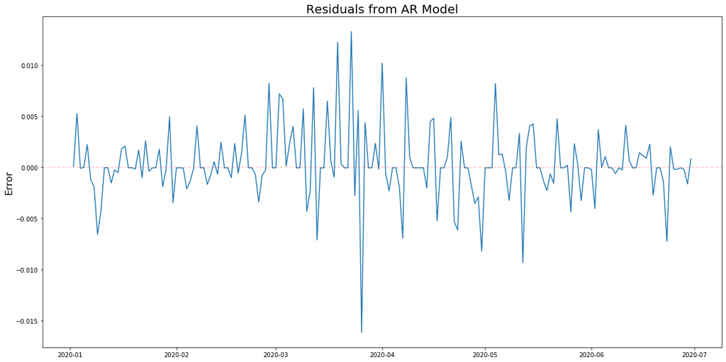

```python
pred_start_date = test_data_returns.index[0]
pred_end_date = test_data_returns.index[-1]
predictions = arma_model_fit.predict(start=pred_start_date, end=pred_end_date)
residuals = test_data_returns - predictions

plt.figure(figsize=(20,10))
plt.plot(residuals)
plt.title('Residuals from AR Model', fontsize=20)
plt.ylabel('Error', fontsize=16)
plt.axhline(0, color='r', linestyle='--', alpha=0.2)
```

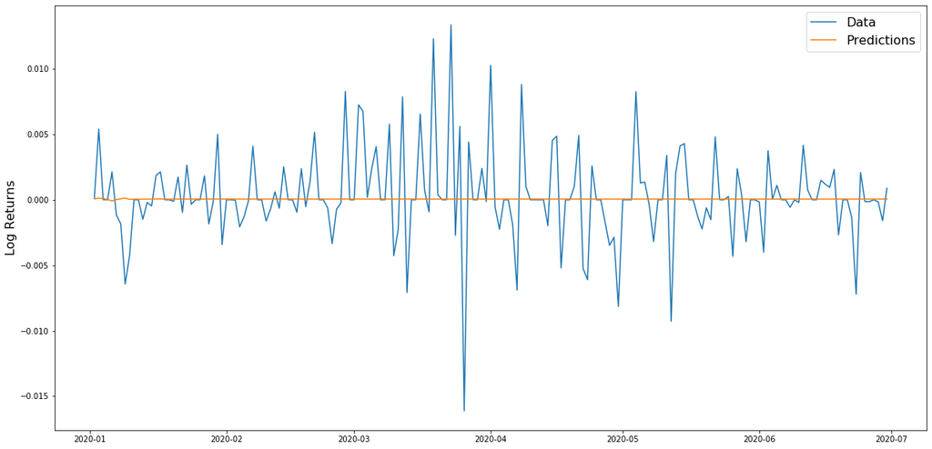

```python
plt.figure(figsize=(20,10))

plt.plot(test_data_returns)
plt.plot(predictions)

plt.legend(('Data', 'Predictions'), fontsize=16)

#plt.title('Exchange Rate Log Returns', fontsize=20)
plt.ylabel('Log Returns', fontsize=16)
```

# ARIMA Model

```
Performing stepwise search to minimize aic
Fit ARIMA(2,0,2)x(0,0,0,0) [intercept=True]; AIC=-13008.177, BIC=-12976.452, Time=0.589 seconds
Fit ARIMA(0,0,0)x(0,0,0,0) [intercept=True]; AIC=-13009.444, BIC=-12998.869, Time=0.148 seconds
Fit ARIMA(1,0,0)x(0,0,0,0) [intercept=True]; AIC=-13007.614, BIC=-12991.751, Time=0.229 seconds
Fit ARIMA(0,0,1)x(0,0,0,0) [intercept=True]; AIC=-13007.622, BIC=-12991.759, Time=0.198 seconds
Fit ARIMA(0,0,0)x(0,0,0,0) [intercept=False]; AIC=-13010.949, BIC=-13005.661, Time=0.057 seconds
Fit ARIMA(1,0,1)x(0,0,0,0) [intercept=True]; AIC=-13004.803, BIC=-12983.653, Time=0.560 seconds
Total fit time: 1.785 seconds
```

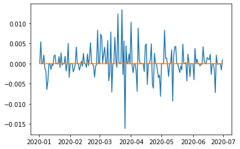

```python
#building the model
from pmdarima import auto_arima
model = auto_arima(train_data_returns, trace=True, error_action='ignore', suppress_warnings=True)
model.fit(train_data_returns)

forecast = model.predict(n_periods=len())
forecast = pd.DataFrame(forecast,index = test_data_returns.index,columns=['Prediction'])

#plot the predictions for validation set
#plt.plot(train_data_returns, label='Train')
plt.plot(test_data_returns, label='Valid')
plt.plot(forecast, label='Prediction')
plt.show()
```

```python
arima_model = ARIMA(train_data_returns, order=(1,0,1))
arima_model_fit = arima_model.fit()
print(arima_model_fit.summary())
```

```
                              ARMA Model Results
==============================================================================
Dep. Variable:                returns   No. Observations:                 1462
Model:                     ARMA(1, 1)   Log Likelihood                6507.015
Method:                       css-mle   S.D. of innovations              0.003
Date:                Tue, 14 Jul 2020   AIC                         -13006.029
Time:                        04:29:27   BIC                         -12984.879
Sample:                    01-01-2016   HQIC                        -12998.140
                         - 01-01-2020
=================================================================================
                    coef    std err          z      P>|z|      [0.025      0.975]
---------------------------------------------------------------------------------
const          5.198e-05   7.47e-05      0.695      0.487   -9.45e-05       0.000
ar.L1.returns    -0.4657      0.595     -0.782      0.434      -1.633       0.701
ma.L1.returns     0.4834      0.588      0.822      0.411      -0.669       1.636
                                    Roots
=============================================================================
                  Real          Imaginary           Modulus         Frequency
-----------------------------------------------------------------------------
AR.1           -2.1471           +0.0000j            2.1471            0.5000
MA.1           -2.0686           +0.0000j            2.0686            0.5000
-----------------------------------------------------------------------------
```

### Ljung-Box Test

$H_0$: The residuals are uncorrelated. $H_1$: The residuals are correlated.

```python
res = sm.tsa.ARMA(train_data_returns, (10,1)).fit(disp=-1)
sm.stats.acorr_ljungbox(res.resid, lags=[10], return_df=True)
```

|  | lb_stat | lb_pvalue |
| --- | --- | --- |
| 10 | 0.048556 | 1.0 |

```python
res = sm.tsa.ARIMA(train_data_returns, (1,0,1)).fit(disp=-1)
sm.stats.acorr_ljungbox(res.resid, lags=[10], return_df=True)
```

|  | lb_stat | lb_pvalue |
| --- | --- | --- |
| 10 | 16.478501 | 0.08673 |

Thus, for both models, with p-value>0.05, we accept the null that the residuals are uncorrelated.

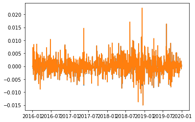

```python
plt.plot(res.resid, label='Valid')
plt.plot(train_data_returns, label='Valid')
```

The fact that we cannot use this model to forecast effectively means that the model residuals are closer to being white noise. However, even in this case there could be volatility clustering, ie., periods of high volatility followed by periods of high volatility and vice versa.

Therefore, we use ARCH, GARCH models.

Back to Project Page.  
Back to Home Page.